# Chapter 5

# Libraries

```r
library(conjanal)
library(ggplot2)
library(reshape2)
```

# Example 1: `cleanser` data

- 18 for most preferred (because have 18 profiles)
- 1 for least preferred
- Highest values must be most preferred and lowest must be least preferred for the program to work
- Each row is a profile. Last 3 rows for prediction (choice simulation only)
- Must convert to factor for program to work
- Sum of part-worth is 0 (set by using `contrasts`)

```r
clean <-read.csv("/Users/jasonchan/MSTAT/STAT8019_Marketing_Analytics/lecture notes/r5/cleanser.csv")

head(clean)
```

|  | color | form | scent | r1 | r2 |
| --- | --- | --- | --- | --- | --- |
| 1 | 1 | 1 | 1 | 3 | 17 |
| 2 | 1 | 1 | 2 | 4 | 18 |
| 3 | 1 | 2 | 1 | 10 | 14 |
| 4 | 1 | 2 | 2 | 16 | 16 |
| 5 | 1 | 3 | 1 | 9 | 10 |
| 6 | 1 | 3 | 2 | 15 | 12 |

```r
#define factors
clean$color<-factor(clean$color,levels=c(1,2,3),labels=c("red","blue","yellow"))
clean$form<-factor(clean$form,levels=c(1,2,3),labels=c("cubic","cylinder","spherical"))
clean$scent<-factor(clean$scent,levels=c(1,2),labels=c("yes","no"))
```

```r
head(clean)
```

|  | color | form | scent | r1 | r2 |
| --- | --- | --- | --- | --- | --- |
| 1 | red | cubic | yes | 3 | 17 |
| 2 | red | cubic | no | 4 | 18 |
| 3 | red | cylinder | yes | 10 | 14 |
| 4 | red | cylinder | no | 16 | 16 |
| 5 | red | spherical | yes | 9 | 10 |
| 6 | red | spherical | no | 15 | 12 |

## Data Preparation

- Next chapter is choice based
- Monotonic Anova

### Step 1: Set Contrasts for Sum of Part Worths to be 0

```r
#set contrasts, sum=0
contrasts(clean$color)<-contr.sum(3)
contrasts(clean$form)<-contr.sum(3)
contrasts(clean$scent)<-contr.sum(2)
```

### Step 2: Train, Test Split

```r
# train test split
# scenarios
csimp<-clean[19:21,1:3]
clean<-clean[1:18,]
```

```r
clean
```

|  | color | form | scent | r1 | r2 |
| --- | --- | --- | --- | --- | --- |
| 1 | red | cubic | yes | 3 | 17 |
| 2 | red | cubic | no | 4 | 18 |
| 3 | red | cylinder | yes | 10 | 14 |
| 4 | red | cylinder | no | 16 | 16 |
| 5 | red | spherical | yes | 9 | 10 |
| 6 | red | spherical | no | 15 | 12 |
| 7 | blue | cubic | yes | 2 | 6 |
| 8 | blue | cubic | no | 1 | 13 |
| 9 | blue | cylinder | yes | 7 | 3 |
| 10 | blue | cylinder | no | 12 | 8 |

[output cut: 8 more lines]

```r
csimp
```

|  | color | form | scent |
| --- | --- | --- | --- |
| 19 | blue | cubic | yes |
| 20 | red | cylinder | yes |
| 21 | red | spherical | no |

### Step 3: Create Response Matrix and Profile of Training Data

- The respondents column of the training data

```r
#define response matrix
resp<-as.matrix(clean[,4:5])

#define profiles
profile<-clean[,1:3]
```

### Step 4: Apply Conjoint Analysis

- Because using ranking, `monotone=True`. Monotonic transformation.

```r
#conjanal() metric conjoint analysis
#resp= matrix of responses
#profile= data frame of designs
#iv= factors
fit.conj<-conjanal(resp=resp,profile=profile,monotone = T)
summary(fit.conj$lm)
```

```
Response r1 :

Call:
lm(formula = r1 ~ color + form + scent, data = profile)

Residuals:
     Min       1Q   Median       3Q      Max
-1.38040 -0.18207 -0.03805  0.23913  1.22818

Coefficients:
              Estimate Std. Error t value Pr(>|t|)
(Intercept)  9.500e+00  1.358e-01  69.967  < 2e-16 ***
color1      -1.374e-05  1.920e-01   0.000        1
color2      -3.062e+00  1.920e-01 -15.944 1.93e-09 ***
form1       -6.123e+00  1.920e-01 -31.887 5.71e-13 ***
form2        3.062e+00  1.920e-01  15.944 1.93e-09 ***
scent1      -1.304e+00  1.358e-01  -9.606 5.52e-07 ***
---
Signif. codes:  0 ‘***’ 0.001 ‘**’ 0.01 ‘*’ 0.05 ‘.’ 0.1 ‘ ’ 1

Residual standard error: 0.5761 on 12 degrees of freedom
Multiple R-squared:  0.9918,    Adjusted R-squared:  0.9884
F-statistic: 289.6 on 5 and 12 DF,  p-value: 4.473e-12


Response r2 :

Call:
lm(formula = r2 ~ color + form + scent, data = profile)

Residuals:
     Min       1Q   Median       3Q      Max
-0.82720 -0.16604 -0.00198  0.22836  0.48602

Coefficients:
            Estimate Std. Error t value Pr(>|t|)
(Intercept)   9.5000     0.0932 101.929  < 2e-16 ***
color1        5.0207     0.1318  38.091 6.90e-14 ***
color2       -3.3596     0.1318 -25.489 8.09e-12 ***
form1         3.7155     0.1318  28.189 2.46e-12 ***
form2        -0.2539     0.1318  -1.926   0.0781 .
scent1       -2.2605     0.0932 -24.254 1.45e-11 ***
---
Signif. codes:  0 ‘***’ 0.001 ‘**’ 0.01 ‘*’ 0.05 ‘.’ 0.1 ‘ ’ 1

Residual standard error: 0.3954 on 12 degrees of freedom
Multiple R-squared:  0.9961,    Adjusted R-squared:  0.9945
F-statistic: 617.3 on 5 and 12 DF,  p-value: 4.922e-14
```

```r
#contrasts of factors
contrasts(clean$form)
```

```
          [,1] [,2]
cubic        1    0
cylinder     0    1
spherical   -1   -1
```

```r
contrasts(clean$color)
```

```
       [,1] [,2]
red       1    0
blue      0    1
yellow   -1   -1
```

```r
contrasts(clean$scent)
```

```
    [,1]
yes    1
no    -1
```

```r
#part-worth
fit.conj$part
```

```
                     r1         r2
red       -1.373984e-05  5.0207547
blue      -3.061516e+00 -3.3596183
yellow     3.061529e+00 -1.6611365
cubic     -6.123014e+00  3.7155523
cylinder   3.061507e+00 -0.2538641
spherical  3.061507e+00 -3.4616882
yes       -1.304291e+00 -2.2605185
no         1.304291e+00  2.2605185
```

```r
#relative importance
fit.conj$imp
```

```
             r1        r2
color 0.3417613 0.4173773
form  0.5126393 0.3574563
scent 0.1455995 0.2251664
```

For `r1`:

- Form is the most important factor accounting for 51%
- Second most important is color
- Yellow is the most important color as it has the highest part worths among all colours
- Cylinder most preferred
- No scent
- Optimal profile is yellow, cylinder, no scent

For `r2`:

- Color is the most important factor accounting for 42%
- Red, cubic, no scent is preferred

## Predict Utility

- Predict for individual customer

```r
csimp
```

|  | color | form | scent |
| --- | --- | --- | --- |
| 19 | blue | cubic | yes |
| 20 | red | cylinder | yes |
| 21 | red | spherical | no |

### Train Test set predict

```r
#predicted utilities
cbind(profile,pred=predict(fit.conj$lm,newdata=profile))
```

|  | color | form | scent | pred.r1 | pred.r2 |
| --- | --- | --- | --- | --- | --- |
| 1 | red | cubic | yes | 2.0726815 | 15.975788 |
| 2 | red | cubic | no | 4.6812634 | 20.496826 |
| 3 | red | cylinder | yes | 11.2572022 | 12.006372 |
| 4 | red | cylinder | no | 13.8657841 | 16.527409 |
| 5 | red | spherical | yes | 11.2572022 | 8.798548 |
| 6 | red | spherical | no | 13.8657841 | 13.319585 |
| 7 | blue | cubic | yes | -0.9888204 | 7.595415 |
| 8 | blue | cubic | no | 1.6197615 | 12.116453 |
| 9 | blue | cylinder | yes | 8.1957003 | 3.625999 |
| 10 | blue | cylinder | no | 10.8042822 | 8.147036 |

[output cut: 8 more lines]

```r
cbind(csimp,pred=predict(fit.conj$lm,newdata=csimp))
```

|  | color | form | scent | pred.r1 | pred.r2 |
| --- | --- | --- | --- | --- | --- |
| 19 | blue | cubic | yes | -0.9888204 | 7.595415 |
| 20 | red | cylinder | yes | 11.2572022 | 12.006372 |
| 21 | red | spherical | no | 13.8657841 | 13.319585 |

- negative predictions do happen because of linear model, no bounds

## Market Share (choice simulation)

### Maximum Util

```r
#maxconj() maximum utility
#conjanal= result by conjanal()
#simp= scenarios data frame
maxconj(conjanal=fit.conj,simp=csimp)
```

|  | color | form | scent | share |
| --- | --- | --- | --- | --- |
| 19 | blue | cubic | yes | 0 |
| 20 | red | cylinder | yes | 0 |
| 21 | red | spherical | no | 1 |

```r
NA
```

### BTL

```r
#btlconj() BTL model
btlconj(conjanal=fit.conj,simp=csimp)
```

|  | color | form | scent | share |
| --- | --- | --- | --- | --- |
| 19 | blue | cubic | yes | 0.09487101 |
| 20 | red | cylinder | yes | 0.41557048 |
| 21 | red | spherical | no | 0.48955851 |

### Logit

```r
#logitconj() logit model
logitconj(conjanal=fit.conj,simp=csimp)
```

|  | color | form | scent | share |
| --- | --- | --- | --- | --- |
| 19 | blue | cubic | yes | 0.001283773 |
| 20 | red | cylinder | yes | 0.139996849 |
| 21 | red | spherical | no | 0.858719378 |

# Example 2 (sneakers data)

- Full profile approach
- Fractional design (9 profiles only instead of 27)

```r
sneaker <- read.csv("/Users/jasonchan/MSTAT/STAT8019_Marketing_Analytics/lecture notes/r5/sneaker.csv")

sneaker
```

| COL1 | COL2 | COL3 | COL4 | COL5 | COL6 | COL7 | COL8 | COL9 | COL10 | COL11 | COL12 | COL13 | COL14 | COL15 | COL16 | COL17 | COL18 | COL19 | COL20 | COL21 | COL22 | COL23 | col24 | col25 | col26 | col27 | col28 | col29 | col30 | … |
| --- | --- | --- | --- | --- | --- | --- | --- | --- | --- | --- | --- | --- | --- | --- | --- | --- | --- | --- | --- | --- | --- | --- | --- | --- | --- | --- | --- | --- | --- | --- |
| 1 | 1 | 1 | 6 | 7 | 8 | 5 | 6 | 6 | 7 | 6 | 7 | 5 | 6 | 7 | 6 | 5 | 6 | 6 | 6 | 7 | 6 | 6 | 6 | 7 | 6 | 5 | 7 | 7 | 6 | … |
| 1 | 2 | 2 | 6 | 5 | 5 | 4 | 5 | 6 | 5 | 3 | 5 | 5 | 4 | 5 | 6 | 5 | 4 | 7 | 5 | 4 | 5 | 5 | 5 | 6 | 6 | 5 | 6 | 8 | 7 | … |
| 1 | 3 | 3 | 3 | 3 | 4 | 3 | 3 | 5 | 2 | 3 | 4 | 4 | 3 | 3 | 3 | 3 | 3 | 2 | 3 | 3 | 3 | 3 | 3 | 3 | 5 | 5 | 4 | 5 | 3 | … |
| 2 | 1 | 2 | 4 | 5 | 5 | 4 | 3 | 5 | 5 | 4 | 4 | 5 | 5 | 3 | 4 | 4 | 4 | 4 | 4 | 5 | 4 | 4 | 4 | 4 | 4 | 4 | 4 | 4 | 3 | … |
| 2 | 2 | 3 | 3 | 3 | 3 | 3 | 2 | 4 | 2 | 3 | 2 | 2 | 2 | 3 | 4 | 4 | 4 | 1 | 4 | 3 | 3 | 3 | 1 | 2 | 2 | 4 | 3 | 3 | 2 | … |
| 2 | 3 | 1 | 4 | 4 | 4 | 5 | 5 | 4 | 3 | 5 | 4 | 5 | 4 | 4 | 4 | 4 | 4 | 4 | 5 | 4 | 4 | 5 | 4 | 4 | 3 | 3 | 4 | 4 | 4 | … |
| 3 | 1 | 3 | 3 | 3 | 4 | 4 | 5 | 2 | 2 | 4 | 3 | 3 | 3 | 2 | 2 | 3 | 2 | 4 | 4 | 5 | 3 | 3 | 3 | 4 | 3 | 3 | 1 | 4 | 3 | … |
| 3 | 2 | 1 | 5 | 5 | 5 | 4 | 5 | 4 | 5 | 4 | 6 | 6 | 5 | 4 | 5 | 5 | 5 | 5 | 4 | 6 | 5 | 5 | 5 | 4 | 5 | 5 | 5 | 5 | 4 | … |
| 3 | 3 | 2 | 4 | 4 | 4 | 3 | 3 | 3 | 4 | 5 | 2 | 3 | 3 | 3 | 3 | 4 | 4 | 4 | 5 | 4 | 4 | 3 | 3 | 2 | 3 | 4 | 3 | 3 | 4 | … |

- Rows describe the profile
- Columns describe the responses

## Data Prep

```r
#define factors
sneaker$COL1<-factor(sneaker$COL1,levels=c(1,2,3),labels=c("rubber","polyurethane","plastic"))
sneaker$COL2<-factor(sneaker$COL2,levels=c(1,2,3),labels=c("leather","canvas","nylon"))
sneaker$COL3<-factor(sneaker$COL3,levels=c(1,2,3),labels=c("30","60","90"))

#set contrasts, sum=0
contrasts(sneaker$COL1)<-contr.sum(3)
contrasts(sneaker$COL2)<-contr.sum(3)
contrasts(sneaker$COL3)<-contr.sum(3)

#define response matrix
resp<-as.matrix(sneaker[,4:63])

#define profiles
profile<-sneaker[,1:3]
```

```r
sneaker
```

| COL1 | COL2 | COL3 | COL4 | COL5 | COL6 | COL7 | COL8 | COL9 | COL10 | COL11 | COL12 | COL13 | COL14 | COL15 | COL16 | COL17 | COL18 | COL19 | COL20 | COL21 | COL22 | COL23 | col24 | col25 | col26 | col27 | col28 | col29 | col30 | … |
| --- | --- | --- | --- | --- | --- | --- | --- | --- | --- | --- | --- | --- | --- | --- | --- | --- | --- | --- | --- | --- | --- | --- | --- | --- | --- | --- | --- | --- | --- | --- |
| rubber | leather | 30 | 6 | 7 | 8 | 5 | 6 | 6 | 7 | 6 | 7 | 5 | 6 | 7 | 6 | 5 | 6 | 6 | 6 | 7 | 6 | 6 | 6 | 7 | 6 | 5 | 7 | 7 | 6 | … |
| rubber | canvas | 60 | 6 | 5 | 5 | 4 | 5 | 6 | 5 | 3 | 5 | 5 | 4 | 5 | 6 | 5 | 4 | 7 | 5 | 4 | 5 | 5 | 5 | 6 | 6 | 5 | 6 | 8 | 7 | … |
| rubber | nylon | 90 | 3 | 3 | 4 | 3 | 3 | 5 | 2 | 3 | 4 | 4 | 3 | 3 | 3 | 3 | 3 | 2 | 3 | 3 | 3 | 3 | 3 | 3 | 5 | 5 | 4 | 5 | 3 | … |
| polyurethane | leather | 60 | 4 | 5 | 5 | 4 | 3 | 5 | 5 | 4 | 4 | 5 | 5 | 3 | 4 | 4 | 4 | 4 | 4 | 5 | 4 | 4 | 4 | 4 | 4 | 4 | 4 | 4 | 3 | … |
| polyurethane | canvas | 90 | 3 | 3 | 3 | 3 | 2 | 4 | 2 | 3 | 2 | 2 | 2 | 3 | 4 | 4 | 4 | 1 | 4 | 3 | 3 | 3 | 1 | 2 | 2 | 4 | 3 | 3 | 2 | … |
| polyurethane | nylon | 30 | 4 | 4 | 4 | 5 | 5 | 4 | 3 | 5 | 4 | 5 | 4 | 4 | 4 | 4 | 4 | 4 | 5 | 4 | 4 | 5 | 4 | 4 | 3 | 3 | 4 | 4 | 4 | … |
| plastic | leather | 90 | 3 | 3 | 4 | 4 | 5 | 2 | 2 | 4 | 3 | 3 | 3 | 2 | 2 | 3 | 2 | 4 | 4 | 5 | 3 | 3 | 3 | 4 | 3 | 3 | 1 | 4 | 3 | … |
| plastic | canvas | 30 | 5 | 5 | 5 | 4 | 5 | 4 | 5 | 4 | 6 | 6 | 5 | 4 | 5 | 5 | 5 | 5 | 4 | 6 | 5 | 5 | 5 | 4 | 5 | 5 | 5 | 5 | 4 | … |
| plastic | nylon | 60 | 4 | 4 | 4 | 3 | 3 | 3 | 4 | 5 | 2 | 3 | 3 | 3 | 3 | 4 | 4 | 4 | 5 | 4 | 4 | 3 | 3 | 2 | 3 | 4 | 3 | 3 | 4 | … |

## ANOVA Model

- Has numerical and categorical, so ANOVA, not MONOANOVA

```r
#ANOVA model
fit.lm<-lm(COL4 ~ COL1 + COL2 + COL3, data=sneaker)
summary(fit.lm)
```

```
Call:
lm(formula = COL4 ~ COL1 + COL2 + COL3, data = sneaker)

Residuals:
      1       2       3       4       5       6       7       8       9
 0.1111  0.1111 -0.2222 -0.2222  0.1111  0.1111  0.1111 -0.2222  0.1111

Coefficients:
            Estimate Std. Error t value Pr(>|t|)
(Intercept)   4.2222     0.1111  38.000 0.000692 ***
COL11         0.7778     0.1571   4.950 0.038476 *
COL12        -0.5556     0.1571  -3.536 0.071523 .
COL21         0.1111     0.1571   0.707 0.552786
COL22         0.4444     0.1571   2.828 0.105573
COL31         0.7778     0.1571   4.950 0.038476 *
COL32         0.4444     0.1571   2.828 0.105573
---
Signif. codes:  0 ‘***’ 0.001 ‘**’ 0.01 ‘*’ 0.05 ‘.’ 0.1 ‘ ’ 1

Residual standard error: 0.3333 on 2 degrees of freedom
Multiple R-squared:  0.9808,    Adjusted R-squared:  0.9231
F-statistic:    17 on 6 and 2 DF,  p-value: 0.05659
```

- Not ranked data, so `monotone=F`

```r
fit.conj<-conjanal(resp,profile,monotone=F)
fit.summary<-summary(fit.conj$lm)
```

```
essentially perfect fit: summary may be unreliableessentially perfect fit: summary may be unreliable
```

```r
fit.summary$`Response COL4`
```

```
Call:
lm(formula = COL4 ~ COL1 + COL2 + COL3, data = profile)

Residuals:
      1       2       3       4       5       6       7       8       9
 0.1111  0.1111 -0.2222 -0.2222  0.1111  0.1111  0.1111 -0.2222  0.1111

Coefficients:
            Estimate Std. Error t value Pr(>|t|)
(Intercept)   4.2222     0.1111  38.000 0.000692 ***
COL11         0.7778     0.1571   4.950 0.038476 *
COL12        -0.5556     0.1571  -3.536 0.071523 .
COL21         0.1111     0.1571   0.707 0.552786
COL22         0.4444     0.1571   2.828 0.105573
COL31         0.7778     0.1571   4.950 0.038476 *
COL32         0.4444     0.1571   2.828 0.105573
---
Signif. codes:  0 ‘***’ 0.001 ‘**’ 0.01 ‘*’ 0.05 ‘.’ 0.1 ‘ ’ 1

Residual standard error: 0.3333 on 2 degrees of freedom
Multiple R-squared:  0.9808,    Adjusted R-squared:  0.9231
F-statistic:    17 on 6 and 2 DF,  p-value: 0.05659
```

### Part Worth and VarImp

```r
#display the first respondent
fit.conj$part[,1]
```

```
      rubber polyurethane      plastic      leather       canvas
   0.7777778   -0.5555556   -0.2222222    0.1111111    0.4444444
       nylon           30           60           90
  -0.5555556    0.7777778    0.4444444   -1.2222222
```

```r
fit.conj$imp[,1]
```

```
     COL1      COL2      COL3
0.3076923 0.2307692 0.4615385
```

## Cluster Analysis

- Cluster the customers based on variable importance
- transpose data structure and then sscale it

### Hclust

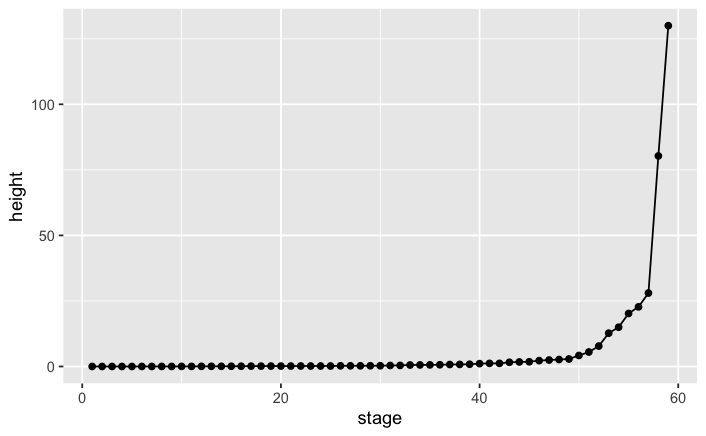

```r
# standardize relative importance
imp<-data.frame(scale(t(fit.conj$imp)))
#Ward's method
dist<-dist(imp,method="euclidean")^2
clust <- hclust(dist, method="ward.D")

ggplot(mapping=aes(x=1:length(clust$height),y=clust$height))+
  geom_line()+
  geom_point()+
  labs(x="stage",y="height")
```

- 3 clusters recommended

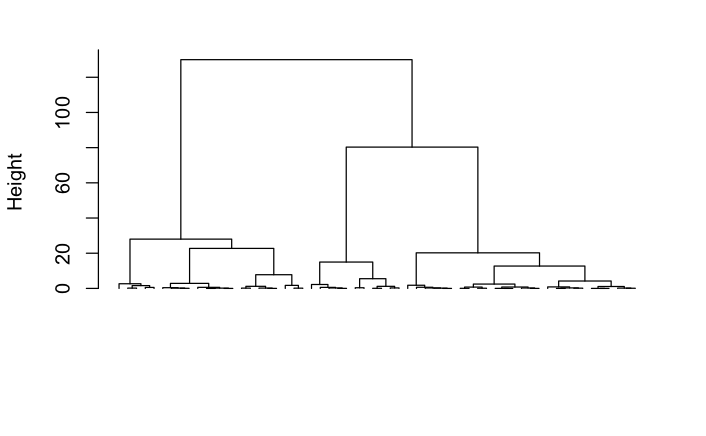

```r
#par(mar=c(1,4,1,1))
plot(clust,labels=F,hang=-1,sub="",xlab="",main="")
```

### K-means

- Optimized grouping

```r
set.seed(123)
fit1<-kmeans(x=imp,centers=3)
fit1
```

```
K-means clustering with 3 clusters of sizes 17, 20, 23

Cluster means:
        COL1       COL2       COL3
1  1.1658377 -0.5055128 -0.7848532
2 -0.7076888 -0.5742574  1.0907050
3 -0.2463246  0.8729942 -0.3683303

Clustering vector:
 COL4  COL5  COL6  COL7  COL8  COL9 COL10 COL11 COL12 COL13 COL14 COL15
    2     2     3     2     2     1     2     3     2     2     2     2
COL16 COL17 COL18 COL19 COL20 COL21 COL22 COL23 col24 col25 col26 col27
    3     3     2     2     2     3     2     2     2     3     1     1
col28 col29 col30 col31 col32 col33 col34 col35 col36 col37 col38 col39
    1     1     1     3     2     1     1     1     3     2     3     3
col40 col41 col42 col43 col44 col45 col46 col47 col48 col49 col50 col51
    1     2     2     3     3     3     1     1     3     3     3     3
col52 col53 col54 col55 col56 col57 col58 col59 col60 col61 col62 col63
    3     3     3     1     2     1     3     3     1     1     3     1

Within cluster sum of squares by cluster:
[1] 21.68711 30.39247 24.54898
 (between_SS / total_SS =  56.7 %)

Available components:

[1] "cluster"      "centers"      "totss"        "withinss"
[5] "tot.withinss" "betweenss"    "size"         "iter"
[9] "ifault"
```

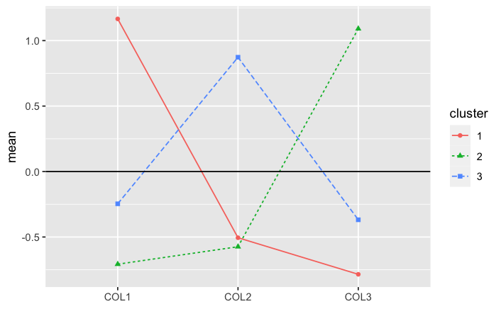

```r
tb<-fit1$centers

tb<-data.frame(cbind(tb,cluster=1:3))
tbm<-melt(tb,id.vars='cluster')
tbm$cluster<-factor(tbm$cluster)
ggplot(tbm,
       aes(x = variable, y = value, group = cluster, colour = cluster)) +
  geom_line(aes(linetype=cluster))+
  geom_point(aes(shape=cluster)) +
  geom_hline(yintercept=0) +
  labs(x=NULL,y="mean")
```